# RecFin Data Overview

Zoë Kitchel

2025-02-07

## 0.1 How we pulled data

- Downloaded RecFin data on January 15, 2025 from [recfin website](https://reports.psmfc.org/recfin/f?p=601:1:13820808312939:INITIAL:::F_SELECTED_NODE:53&cs=3MMX4GLd8uuMBgMGOzscCAHvH_yUely3YcYGno0ODuz8s3Y2PDfjORospWxOA5ztpEkJ4jVH0U06YeC5-Kvv10g)

Filters applied for download:

- Agency = California
- Mode = All (Note, for some reason, there is NO Beach/Bank in 2023-2024)
- Water Area = Ocean (<= 3 miles)
- Subregion = South California
- Trip Type = All

Thoughts

- Not sure why no beach/bank in 2023-2024
  - Beach bank catch estimates only based on online surveys, maybe these haven’t been integrated yet?
  - ALDOS (Angler License Directory Online Survey) is used to collect effort data only for beach and bank fishing, night-time fishing, and private access fishing that might otherwise go unaccounted for.
- Should we include South district (San Diego, Orange, and LA Counties) and Channel district (Ventura and Santa Barbara Counties)? or just South?
  - Ideally, just LA County?
- Options for units are retained count, retained weight, released count, released weight, released dead count, released dead weight, total mortality count, total mortality weight
  - Likely, we’re most interested in Total Mortality count and weight (and therefore that’s what I include below)

Helpful resources and tips

- [NOAA on CDFW-ALDOS](https://www.fisheries.noaa.gov/s3/2023-09/CDFW-ALDOS-PR1-PR2-Certification-OST-2023-Redacted.pdf)
- RecFin data is a Catch Estimate
- 1979 - 2003 = Marine Recreational Statistical Survey (MRFSS)
- 2004 - Present = California Recreational Fisheries Survey (CRFS)
- 1936 - Present = Commercial Passenger Fishing Vessel (CPFV) operators are required to submit logbooks to CDFW that include documentation of each fishing trip
  - Each logbook entry reports effort (# anglers and # hours fished) and take (species and number fish caught)
  - CRFS uses CPFV effort data collected by samplers in the field and logbook records to estimate CPFV effort

## 0.2 Data processing steps

### 0.2.1 I load the data from RecFin website, and merge all CSVs into one.

### 0.2.2 I make some small data adjustments to improve usability.

### 0.2.3 Start by visualizing all RecFin data from 2004-2024

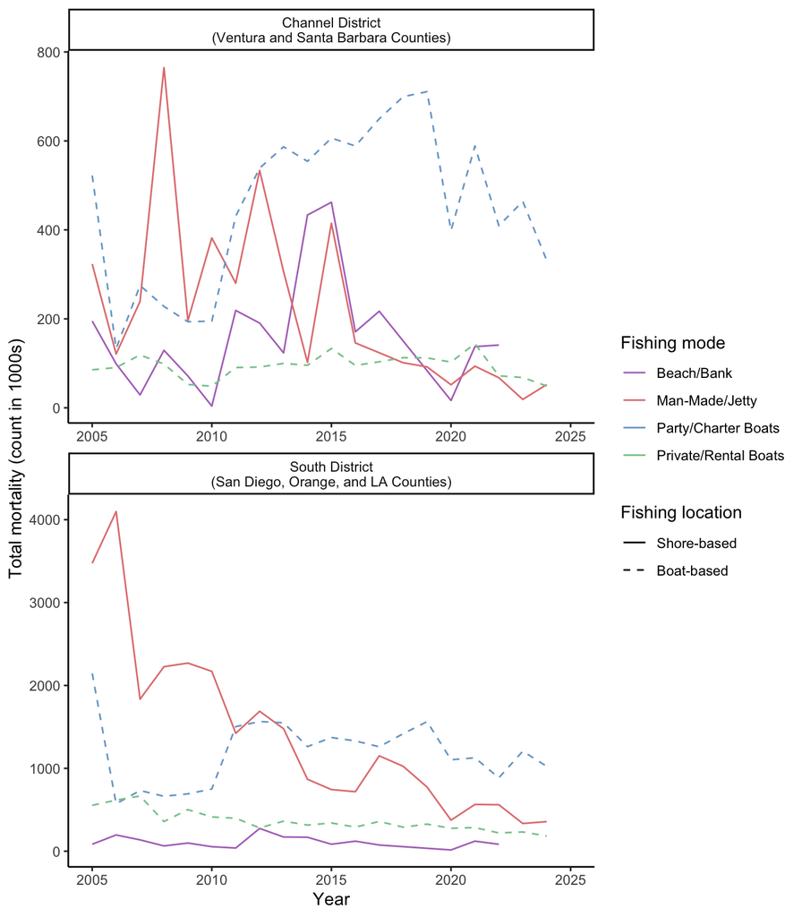

Figure 1: RecFin total estimated fishing mortality by count. Note different y-axis scale for each district. Color specifies fishing mode, line type specifies fishing mode location.

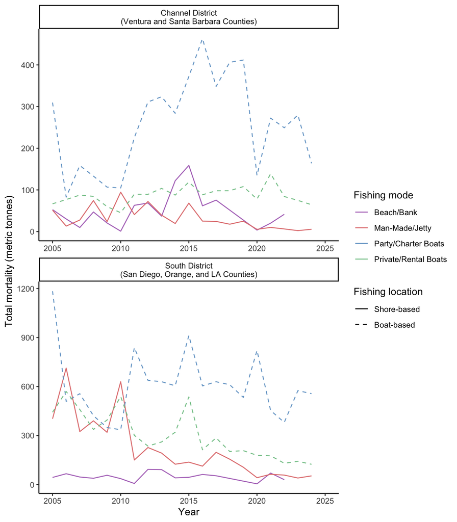

Figure 2: RecFin total estimated fishing mortality by weight. Note different y-axis scale for each district. Color specifies fishing mode, line type specifies fishing mode location.

### 0.2.4 Identify most common species

Table 1: Top species (by count) across both districts and all fishing modes.

| Species | Total mortality 2004-2024 (count in 1000s) |
| --- | --- |
| Pacific (Chub) Mackerel | 17337 |
| Pacific Sardine | 6114 |
| California Scorpionfish | 4088 |
| Vermilion Rockfish | 3411 |
| Rockfish Genus | 3388 |
| Pacific Sanddab | 3197 |
| Ocean Whitefish | 2795 |
| Barred Surfperch | 2758 |
| Kelp Bass | 2196 |
| Bocaccio | 2152 |

Table 2: Top species (by weight) across both districts and all fishing modes.

| Species | Total mortality 2004-2024 (metric tonnes) |
| --- | --- |
| Yellowtail | 3218 |
| Pacific (Chub) Mackerel | 2962 |
| Vermilion Rockfish | 2087 |
| California Scorpionfish | 1874 |
| Pacific Bonito | 1618 |
| Barred Sandbass | 1602 |
| Kelp Bass | 1564 |
| Pacific Barracuda | 1488 |
| Bocaccio | 1480 |
| Ocean Whitefish | 1241 |

Table 3: Top species (by count) for all fishing modes in South District (LA, SD, OC Counties).

| Species | Total mortality South District 2004-2024 (count in 1000s) |
| --- | --- |
| Pacific (Chub) Mackerel | 15684 |
| Pacific Sardine | 4946 |
| California Scorpionfish | 3986 |
| Pacific Sanddab | 2657 |
| Vermilion Rockfish | 2189 |
| Kelp Bass | 1958 |
| Barred Sandbass | 1922 |
| Rockfish Genus | 1917 |
| Northern Anchovy | 1854 |
| Ocean Whitefish | 1567 |

Table 4: Top species (by weight) for all fishing modes in South District (LA, SD, OC Counties).

| Species | Total mortality South District 2004-2024 (metric tonnes) |
| --- | --- |
| Yellowtail | 2971 |
| Pacific (Chub) Mackerel | 2698 |
| California Scorpionfish | 1811 |
| Pacific Bonito | 1534 |
| Barred Sandbass | 1523 |
| Kelp Bass | 1375 |
| Pacific Barracuda | 1252 |
| Vermilion Rockfish | 1154 |
| Squid Class | 820 |
| Bocaccio | 815 |

Table 5: Top species (by count) for shore-based fishing modes in South District (LA, SD, OC Counties).

| Species | Total shore-based mortality South District 2004-2024 (count in 1000s) |
| --- | --- |
| Pacific (Chub) Mackerel | 13605 |
| Pacific Sardine | 4908 |
| Northern Anchovy | 1839 |
| Silverside Family | 1316 |
| Queenfish | 1137 |
| Jacksmelt | 986 |
| Barred Surfperch | 801 |
| Yellowfin Croaker | 604 |
| Walleye Surfperch | 522 |
| Topsmelt | 455 |

Table 6: Top species (by weight) for shore-based fishing modes in South District (LA, SD, OC Counties).

| Species | Total shore-based mortality South District 2004-2024 (metric tonnes) |
| --- | --- |
| Pacific (Chub) Mackerel | 2160 |
| Squid Class | 319 |
| Pacific Sardine | 292 |
| Spotfin Croaker | 253 |
| Pacific Bonito | 183 |
| Jacksmelt | 177 |
| Barred Surfperch | 171 |
| Yellowfin Croaker | 152 |
| Shovelnose Guitarfish | 142 |
| Leopard Shark | 138 |

### 0.2.5 Visualize time series of most common species in South District caught using shore-based methods (Beach/Pier/Jetty).

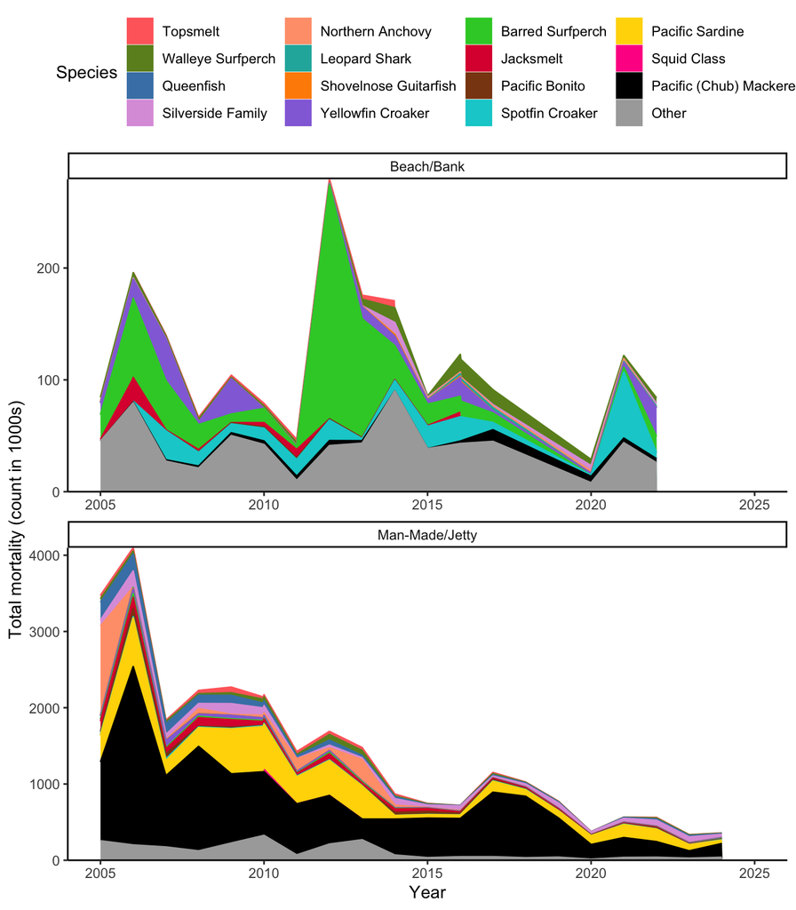

Figure 3: RecFin total estimated mortality count for shore-based fishing in the South District. All species not in the top ten by either count or weight are grouped as Other. Note different y-axis scale for mode. Color identifies species.

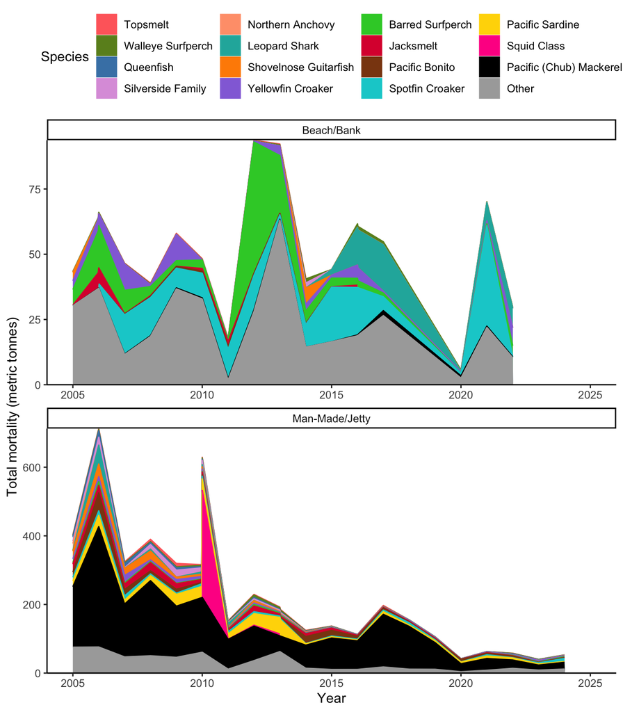

Figure 4: RecFin total estimated mortality weight for shore-based fishing in the South District. All species not in the top ten by either count or weight are grouped as Other. Note different y-axis scale for mode. Color identifies species.

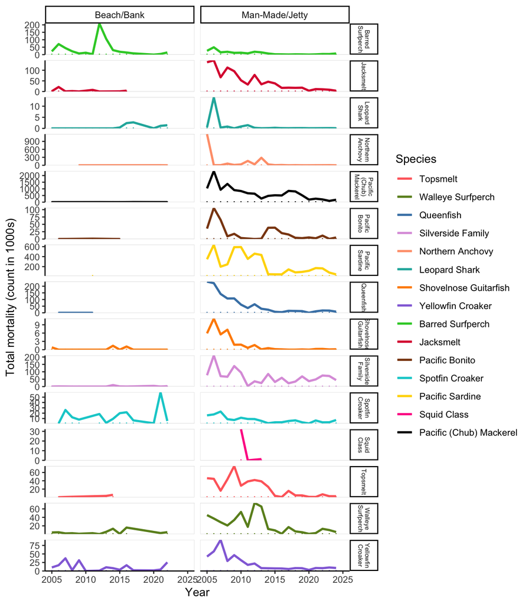

Figure 5: Total estimated mortality (count) for most commonly harvested species (by either weight or count) using shore-based fishing methods in the South District. Data from RecFin. Note different y-axis scale across species. Color identifies species.

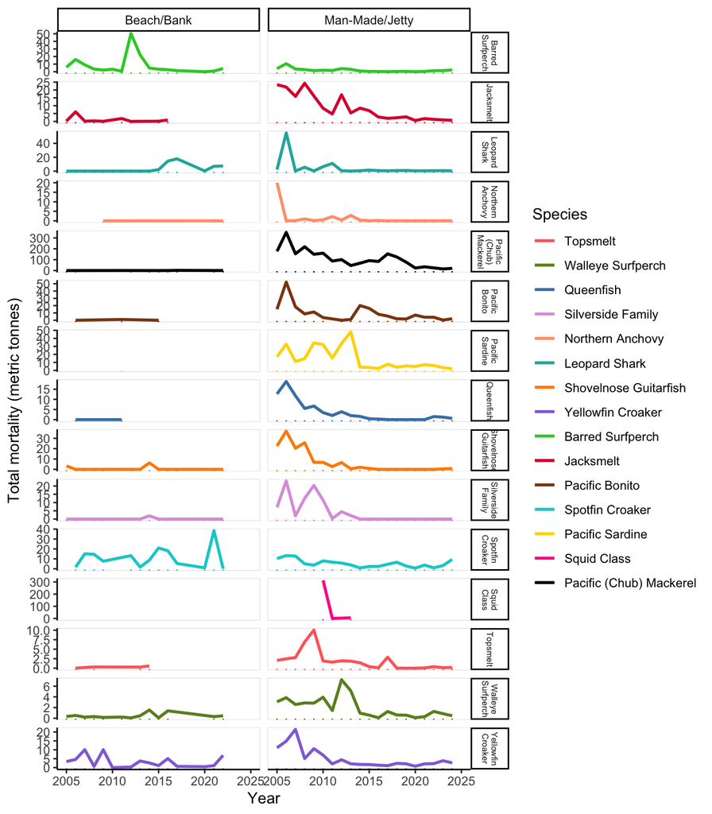

Figure 6: Total estimated mortality (weight) for most commonly harvested species (by either weight or count) using shore-based fishing methods in the South District. Data from RecFin. Note different y-axis scale across species. Color identifies species.

I’m not immediately worried about changes in ID over time for any top species. It would be different if we were looking at rockfish, but no rockfish caught from shore.